# Happiness and Income, Australia vs. Mexico

Ben Jefferies

2024-07-20

## Project Overview

The goal of this report is to analyze the connection between income and happiness. Both of these indicators were measured with self-reported questions.  
For happiness level, respondents rated themselves on a 4 point scale<sup>1</sup>:

- 1 - “not at all happy”
- 2 - “not very happy”
- 3 - “rather happy”
- 4 - “very happy”

For the income level, respondents were asked to place themselves relative to the income groups in their country.

- 1 - Lowest Group
- 10 - Highest Group

*Pre-processing Happiness Data code*

```r
dat <- read.csv("WVS_Cross-National_Wave_7_csv_v6_0.csv")

nrow(dat)  # check total rows 97,220
unique(dat$Q46)  #look at unique values for Q46

nrow(dat) == sum(dat$Q46 == 1) + sum(dat$Q46 == 2) + sum(dat$Q46 == 3) + sum(dat$Q46 == 4) + sum(dat$Q46 == -1) + sum(dat$Q46 == -2) + sum(dat$Q46 == -5)  # confirms there are no missing data rows

dat$Happy <- ifelse(dat$Q46 >= 0, dat$Q46, NA)   #replace non-response with NA

# Change order of data 1 - 4, etc.
# first confirm number of 1's and 4's
sum(dat$Happy == 1, na.rm = T)   # 30093
sum(dat$Happy == 4, na.rm = T)   # 2104

dat <- dat %>%
  mutate(Happy = case_when(Happy == 1 ~ 4,
                          Happy == 2 ~ 3,
                          Happy == 3 ~ 2,
                          Happy == 4 ~ 1))

# confirm switch happened properly
sum(dat$Happy == 1, na.rm = T)   # 2104
sum(dat$Happy == 4, na.rm = T)   # 30093


###  Q288 - Income Levels

## Convert non-response to NA Q288

dat <- dat %>%
  mutate(Q288 = ifelse(Q288 >= 0, Q288, NA))

## Mutate to variable Income

dat <- dat %>%
  mutate(Income = Q288)
```

## Summary Statistics

### Income Levels

Comparing Mexico and Australia means comparing two very different countries in economic terms. According to the [OECD Better Life Index](https://www.oecdbetterlifeindex.org/topics/income/), Australia’s mean household wealth ranks #5 globally compared to Mexico at place #34.

The survey asks respondents to place themselves in the income group, relative to their country, that they see themselves in. The chart below shows the distribution of self-reported income levels for each country, which does reflect what we might imagine when comparing a richer country with a poorer one: in Mexico the majority of respondents place themselves under level 5, while in Australia the distribution looks “normal” around the middle income group.

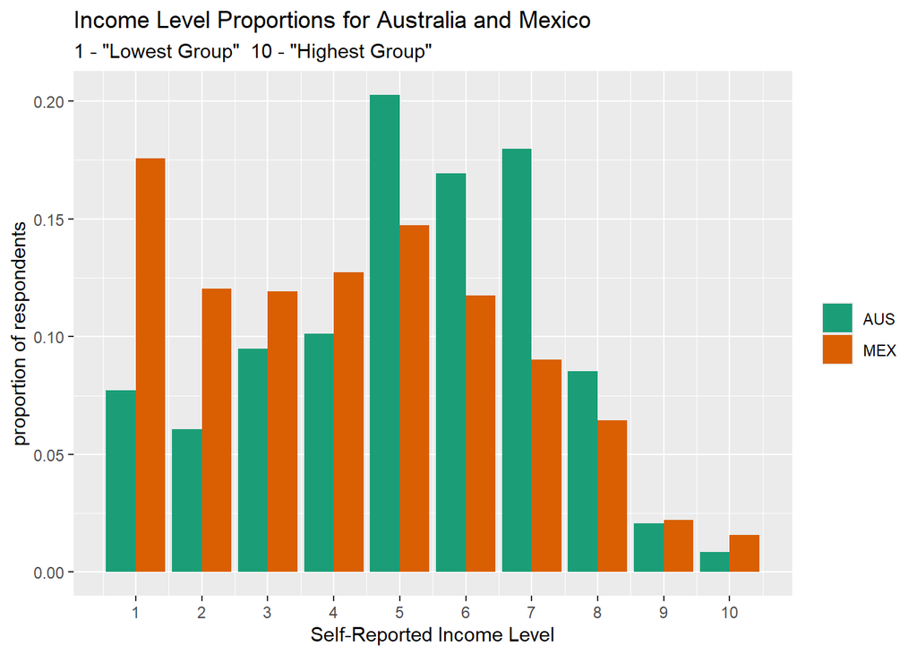

```r
#subset data to only Mexico and Australiaf
sub.mx.aus <- dat[ dat$B_COUNTRY_ALPHA %in% c("MEX", "AUS"), ]

ggplot(data = sub.mx.aus,
       aes(x = Income, fill = factor(B_COUNTRY_ALPHA),
           by = factor(B_COUNTRY_ALPHA),
           y = after_stat(prop))) +
  geom_bar( position = "dodge") +
  labs(title = "Income Level Proportions for Australia and Mexico",
       subtitle = "1 - \"Lowest Group\"  10 - \"Highest Group\"",
       y = "proportion of respondents") +
  theme(legend.title = element_blank()) +
  scale_fill_brewer(palette = "Dark2") +
  scale_x_continuous(name = "Self-Reported Income Level",
                     breaks = c(1:10))
```

### Happiness Levels

On the happiness scale, it can be seen below that a similar proportion in both Mexico and Australia reported being “rather happy” or “very happy”. However, between the two groups a much greater proportion of Mexican respondents reported being very happy. This leads to a higher group mean for Mexico (3.5) than Australia (3.2).

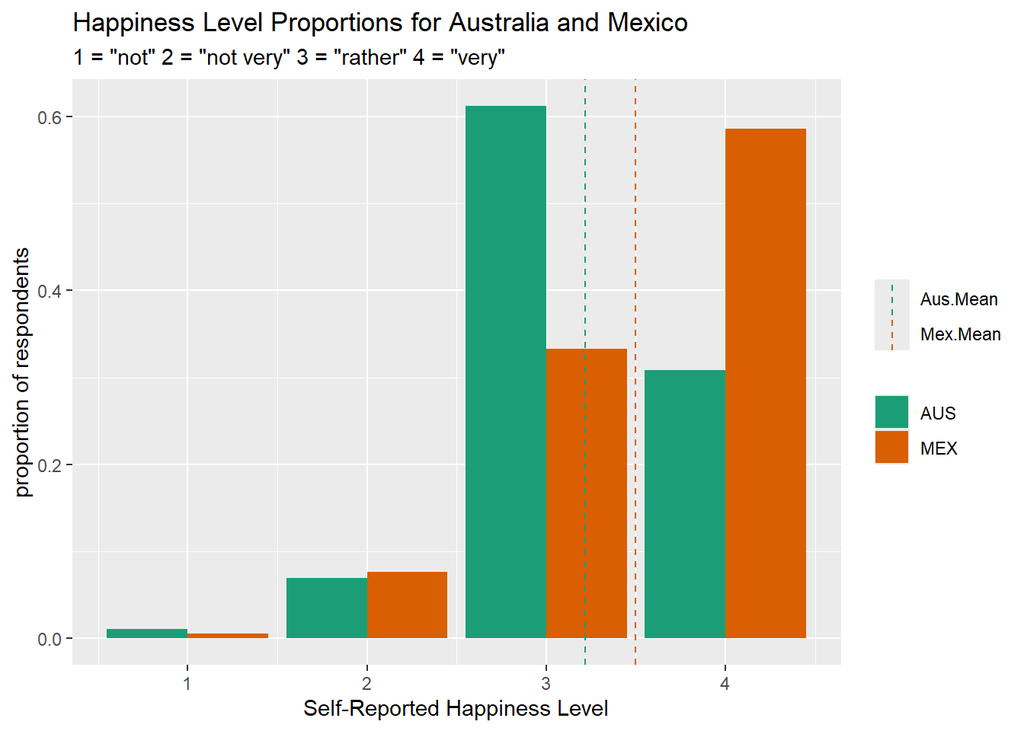

```r
#3.5
mx.avg.happy <- sub.mx.aus %>%
  filter(B_COUNTRY_ALPHA == "MEX") %>%
  pull(Happy) %>%
  mean(, na.rm = T)

#3.2
aus.avg.happy <- sub.mx.aus %>%
  filter(B_COUNTRY_ALPHA == "AUS") %>%
  pull(Happy) %>%
  mean(, na.rm = T)


ggplot(data = sub.mx.aus,
       aes(x = Happy, fill = factor(B_COUNTRY_ALPHA),
           by = factor(B_COUNTRY_ALPHA),
           y = after_stat(prop))) +
  geom_bar( position = "dodge") +
  labs(title = "Happiness Level Proportions for Australia and Mexico",
       subtitle = "1 = \"not\" 2 = \"not very\" 3 = \"rather\" 4 = \"very\"",
       y = "proportion of respondents") +
  theme(legend.title = element_blank()) +
  geom_vline(aes(xintercept = mx.avg.happy,
             color = "Mex.Mean"),
             lty = "dashed") +
  geom_vline(aes(xintercept = aus.avg.happy,
             color = "Aus.Mean"),
             lty = "dashed") +
  scale_fill_brewer(palette = "Dark2") +
  scale_color_manual(name = "Statistics",
                     values = c(Mex.Mean = "#D95F02", Aus.Mean = "#1B9E77")) +
  scale_x_continuous(name = "Self-Reported Happiness Level")
```

**T-Test:** It turns out this is a statistically significant difference in group means (confidence level of 99%), indicating that there is a difference in self-perceived happiness levels between Mexico and Australia.

```r
t.test(Happy ~ B_COUNTRY_ALPHA,
       data = sub.mx.aus)
```

```
##
##  Welch Two Sample t-test
##
## data:  Happy by B_COUNTRY_ALPHA
## t = -13.096, df = 3497.3, p-value < 2.2e-16
## alternative hypothesis: true difference in means between group AUS and group MEX is not equal to 0
## 95 percent confidence interval:
##  -0.3221971 -0.2382844
## sample estimates:
## mean in group AUS mean in group MEX
##          3.217175          3.497415
```

## Correlations

Running a linear regression for both countries shows a statistically significant relationship between an increase in Income and an increase in happiness. The model run describes the following mathematical relationship:

$Happiness = b_0 + b_1 \cdot Income$

### Mexico

In Mexico, the result is a statistically significant (p < 0.01) effect of .02. Meaning for every increase of 1 in a respondents perceived income level (10% change), we expect a .02 increase in reported happiness (0.5% change). This is not a large effect.

```r
sub.mex <- dat[dat$B_COUNTRY_ALPHA == "MEX", ]

fit.happy.mx <- lm(Happy ~ Income, sub.mex)

summary(fit.happy.mx)
```

```
##
## Call:
## lm(formula = Happy ~ Income, data = sub.mex)
##
## Residuals:
##     Min      1Q  Median      3Q     Max
## -2.5707 -0.4911  0.4492  0.5089  0.5686
##
## Coefficients:
##             Estimate Std. Error t value Pr(>|t|)
## (Intercept) 3.411533   0.032442 105.160  < 2e-16 ***
## Income      0.019889   0.006679   2.978  0.00294 **
## ---
## Signif. codes:  0 '***' 0.001 '**' 0.01 '*' 0.05 '.' 0.1 ' ' 1
##
## Residual standard error: 0.6617 on 1717 degrees of freedom
##   (22 observations deleted due to missingness)
## Multiple R-squared:  0.005138,   Adjusted R-squared:  0.004558
## F-statistic: 8.867 on 1 and 1717 DF,  p-value: 0.002944
```

The graph below helps us visualize the relationship over the distribution of happiness responses by income level.

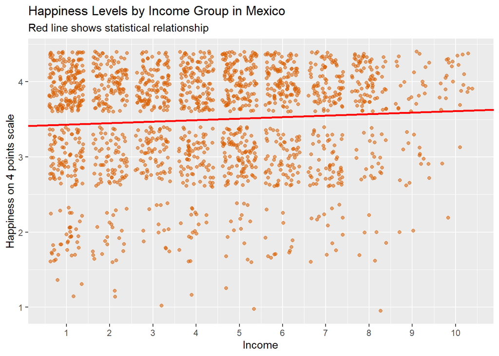

```r
ggplot(data = sub.mex, aes(x = Income, y = Happy)) +
  geom_jitter(aes(alpha = 0.9), colour = "#D95F02") +
  geom_abline(slope = 0.019889,
              intercept = 3.411533,
              color = "red",
              linewidth = 1) +
  scale_x_continuous(name = "Income",
                     breaks = seq(1,10)) +
  scale_y_continuous(name = "Happiness on 4 points scale") +
  ggtitle(label = "Happiness Levels by Income Group in Mexico",
          subtitle = "Red line shows statistical relationship") +
  theme(legend.position = "none")
```

### Australia

In Australia, increases in Income also have a statistically significant effect on Happiness (p < 0.001). The effect is also positive at 0.05, over twice the effect that Income has in Mexico.

```r
sub.aus <- dat[dat$B_COUNTRY_ALPHA == "AUS", ]

fit.happy.aus <- lm(Happy ~ Income, data = sub.aus)

summary(fit.happy.aus)
```

```
##
## Call:
## lm(formula = Happy ~ Income, data = sub.aus)
##
## Residuals:
##     Min      1Q  Median      3Q     Max
## -2.3133 -0.2751 -0.1604  0.6867  0.9925
##
## Coefficients:
##             Estimate Std. Error t value Pr(>|t|)
## (Intercept)  2.95648    0.03759  78.650  < 2e-16 ***
## Income       0.05098    0.00678   7.519 8.77e-14 ***
## ---
## Signif. codes:  0 '***' 0.001 '**' 0.01 '*' 0.05 '.' 0.1 ' ' 1
##
## Residual standard error: 0.5971 on 1742 degrees of freedom
##   (69 observations deleted due to missingness)
## Multiple R-squared:  0.03144,    Adjusted R-squared:  0.03088
## F-statistic: 56.54 on 1 and 1742 DF,  p-value: 8.765e-14
```

The graph of the effect in Australia is presented below.

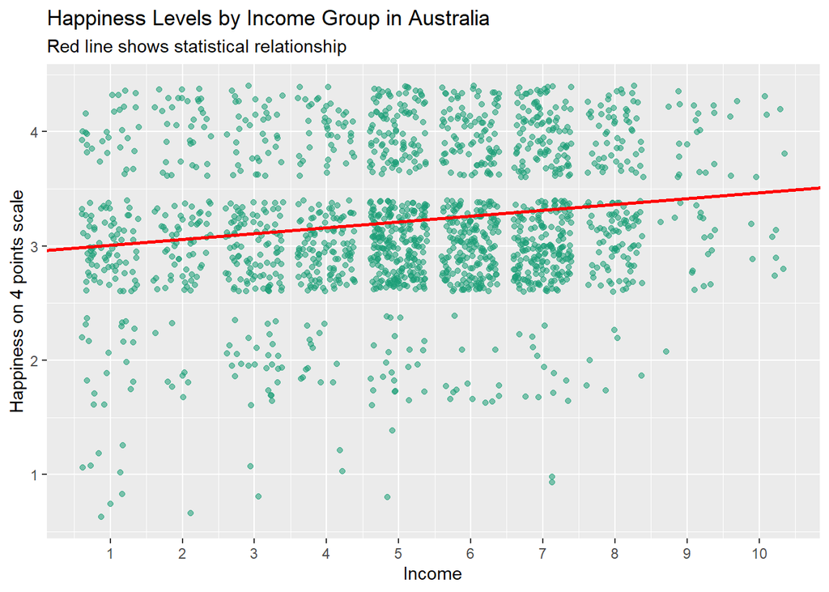

```r
ggplot(data = sub.aus, aes(x = Income, y = Happy)) +
  geom_jitter(aes(alpha = 0.5), colour = "#1B9E77") +
  geom_abline(slope = fit.happy.aus$coefficients[2],
              intercept = fit.happy.aus$coefficients[1],
              color = "red",
              linewidth = 1) +
  scale_x_continuous(name = "Income",
                     breaks = seq(1,10)) +
  scale_y_continuous(name = "Happiness on 4 points scale") +
  ggtitle(label = "Happiness Levels by Income Group in Australia",
          subtitle = "Red line shows statistical relationship") +
  theme(legend.position = "none")
```

### Income Effect Comparison

In order to determine if indeed there is a statistically significant difference between the effect Income has on happiness in Australia compared to Mexico, we can run a multiple regression analysis that incorporates an “interaction term” between Income and Country. If that interaction term’s coefficient is large enough and statistically significant, we can say that there is a difference in the effect income has on happiness depending on what country the respondent lives in.

The mathematical model we now look at takes Australia as the baseline and controls for Mexico as a variable:

$Happiness = b_0 + b_1 \cdot Income + b_2 \cdot Mexico + b_3 \cdot Mex:Income$

**Results:** As can be read below, the interaction term’s coefficient $b_3$ is -0.03 and is statistically significant (p < 0.01). We can therefore conclude that Income has *less* of an effect on happiness in Mexico than it does in Australia.

```r
lm.interact <- lm(Happy ~ Income * B_COUNTRY_ALPHA, data = sub.mx.aus)

summary(lm.interact)
```

```
##
## Call:
## lm(formula = Happy ~ Income * B_COUNTRY_ALPHA, data = sub.mx.aus)
##
## Residuals:
##     Min      1Q  Median      3Q     Max
## -2.5707 -0.4153 -0.1094  0.5288  0.9925
##
## Coefficients:
##                            Estimate Std. Error t value Pr(>|t|)
## (Intercept)                2.956481   0.039662  74.541  < 2e-16 ***
## Income                     0.050978   0.007153   7.126 1.25e-12 ***
## B_COUNTRY_ALPHAMEX         0.455052   0.050270   9.052  < 2e-16 ***
## Income:B_COUNTRY_ALPHAMEX -0.031089   0.009571  -3.248  0.00117 **
## ---
## Signif. codes:  0 '***' 0.001 '**' 0.01 '*' 0.05 '.' 0.1 ' ' 1
##
## Residual standard error: 0.63 on 3459 degrees of freedom
##   (91 observations deleted due to missingness)
## Multiple R-squared:  0.06205,    Adjusted R-squared:  0.06124
## F-statistic: 76.28 on 3 and 3459 DF,  p-value: < 2.2e-16
```

## Summary and Discussion

The results of this investigation lead one to believe that even though people in Mexico see themselves as poorer on average, in line with the statistical reality of the Mexican economy, that does not seem to have much of an effect on their perceived level of happiness. Even though Australia is a much wealthier country overall, that wealth does not translate into greater levels of happiness overall.

As a matter of policy, it seems that increasing personal income in Mexico would have only a very marginal effect on the population’s happiness. The same can be said of Australia in real terms, though in comparison to Mexico the effect would be much larger.

These findings are simple and should not be mistakenly taken as an argument for any causation. There are potentially numerous confounding factors, such as differences in culture and language (for instance, how was the #3 happiness level “rather happy” translated into Spanish). There are also many hundreds of variables that were not accounted for in this statistical analysis.

Interestingly, these findings do fit into a common narrative that people living in poor countries are surprisingly happy and those that live in wealthier countries are less happy, perhaps because of the human tendency to compare ourselves to the perceived wealth of others.

## Footnotes

1. The original question in the survey ranked the happiness questions in inverse order (ie. “very happy” was 1, “not at all happy” was 4). Code block 2 shows the process by which I recoded this variable.